# MINI_PROJECT

## PROBLEM STATEMENT

Use Python (with Pandas, NumPy, Matplotlib, etc.) to explore the dataset and derive meaningful insights. Your goal is to **visualize trends and tell a compelling data story** that can help reduce social media addiction among students.

**DATA DICTIONARY**

**STUDENT ID** - Id allocated to each student who was included into the survey.

**AGE** - Age of the student.

**GENDER** - Gender of the student.

**ACADEMIC LEVEL** - Academic level of the student.

**COUNTRY** - Country of the students.

**AVG DAILY USAGE HRS** - Average daily usage of mobile or mobile applications in hours.

**MOST USED PLATFORM** - Most used platform by the students.

**AFFECTS ACADEMIC PERFORMANCE** - Usage of mobile is affecting their performance or not.

**SLEEP HOURS PER NIGHT** - Sleeping hours per night of individual student.

**MENTAL HEALTH SCORE** - Mental health score of individual student.

**RELATIONSHIP STATUS** - Current relationship status of individual student.

**CONFLICTS OVER SOCIAL MEDIA** - Counts of conflicts over social media.

**ADDICTED SCORE** - Addiction score of individual student.

# Table Of Content

# 1. Import Libraries

```python
import numpy as np
import pandas as pd
import matplotlib.pyplot as plt
import seaborn as sns
```

# 2. Data Understanding and Cleaning

## 2.1 Load The Dataset

```python
# Loading the CSV file to Dataset
dataset = pd.read_csv("Students Social Media Addiction (1).csv")
dataset.head(2)
```

|  | Student_ID | Age | Gender | Academic_Level | Country | Avg_Daily_Usage_Hours | Most_Used_Platform | Affects_Academic_Performance | Sleep_Hours_Per_Night | Mental_Health_Score | Relationship_Status | Conflicts_Over_Social_Media | Addicted_Score |
| --- | --- | --- | --- | --- | --- | --- | --- | --- | --- | --- | --- | --- | --- |
| 0 | 1 | 19 | Female | Undergraduate | Bangladesh | 5.2 | Instagram | Yes | 6.5 | 6 | In Relationship | 3 | 8 |
| 1 | 2 | 22 | Male | Graduate | India | 2.1 | Twitter | No | 7.5 | 8 | Single | 0 | 3 |

## 2.2 Handle Missing Value

```python
# Checking for any missing value over the Dataset
dataset.isna().sum()
```

```
Student_ID                      0
Age                             0
Gender                          0
Academic_Level                  0
Country                         0
Avg_Daily_Usage_Hours           0
Most_Used_Platform              0
Affects_Academic_Performance    0
Sleep_Hours_Per_Night           0
Mental_Health_Score             0
Relationship_Status             0
Conflicts_Over_Social_Media     0
Addicted_Score                  0
dtype: int64
```

## 2.3 DataType Validation And Conversion If Any

```python
# understang the data and checking for the datatype.
dataset.info()
```

```
<class 'pandas.core.frame.DataFrame'>
RangeIndex: 705 entries, 0 to 704
Data columns (total 13 columns):
 #   Column                        Non-Null Count  Dtype
---  ------                        --------------  -----
 0   Student_ID                    705 non-null    int64
 1   Age                           705 non-null    int64
 2   Gender                        705 non-null    object
 3   Academic_Level                705 non-null    object
 4   Country                       705 non-null    object
 5   Avg_Daily_Usage_Hours         705 non-null    float64
 6   Most_Used_Platform            705 non-null    object
 7   Affects_Academic_Performance  705 non-null    object
 8   Sleep_Hours_Per_Night         705 non-null    float64
 9   Mental_Health_Score           705 non-null    int64
 10  Relationship_Status           705 non-null    object
 11  Conflicts_Over_Social_Media   705 non-null    int64
 12  Addicted_Score                705 non-null    int64
dtypes: float64(2), int64(5), object(6)
memory usage: 71.7+ KB
```

```python
dataset.describe()
```

|  | Student_ID | Age | Avg_Daily_Usage_Hours | Sleep_Hours_Per_Night | Mental_Health_Score | Conflicts_Over_Social_Media | Addicted_Score |
| --- | --- | --- | --- | --- | --- | --- | --- |
| count | 705.000000 | 705.000000 | 705.000000 | 705.000000 | 705.000000 | 705.000000 | 705.000000 |
| mean | 353.000000 | 20.659574 | 4.918723 | 6.868936 | 6.226950 | 2.849645 | 6.436879 |
| std | 203.660256 | 1.399217 | 1.257395 | 1.126848 | 1.105055 | 0.957968 | 1.587165 |
| min | 1.000000 | 18.000000 | 1.500000 | 3.800000 | 4.000000 | 0.000000 | 2.000000 |
| 25% | 177.000000 | 19.000000 | 4.100000 | 6.000000 | 5.000000 | 2.000000 | 5.000000 |
| 50% | 353.000000 | 21.000000 | 4.800000 | 6.900000 | 6.000000 | 3.000000 | 7.000000 |
| 75% | 529.000000 | 22.000000 | 5.800000 | 7.700000 | 7.000000 | 4.000000 | 8.000000 |
| max | 705.000000 | 24.000000 | 8.500000 | 9.600000 | 9.000000 | 5.000000 | 9.000000 |

```python
dataset.shape
```

```
(705, 13)
```

```python
dataset.columns
```

```
Index(['Student_ID', 'Age', 'Gender', 'Academic_Level', 'Country',
       'Avg_Daily_Usage_Hours', 'Most_Used_Platform',
       'Affects_Academic_Performance', 'Sleep_Hours_Per_Night',
       'Mental_Health_Score', 'Relationship_Status',
       'Conflicts_Over_Social_Media', 'Addicted_Score'],
      dtype='object')
```

```python
# Numeric Columns
dataset.select_dtypes(exclude='object').columns
```

```
Index(['Student_ID', 'Age', 'Avg_Daily_Usage_Hours', 'Sleep_Hours_Per_Night',
       'Mental_Health_Score', 'Conflicts_Over_Social_Media', 'Addicted_Score'],
      dtype='object')
```

# 3. Exploratory Data Analysis

## 3.1 Relationship Between

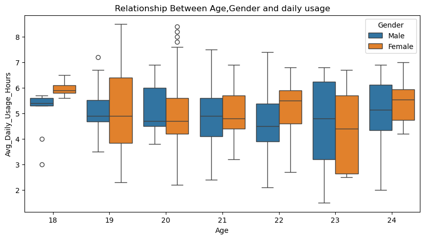

```python
# AGE, GENDER AND DAILY USAGE IN HOURS
plt.figure(figsize=(10,5))
sns.boxplot(x='Age',y='Avg_Daily_Usage_Hours',data=dataset,hue='Gender')
plt.title("Relationship Between Age,Gender and daily usage")
plt.show()
```

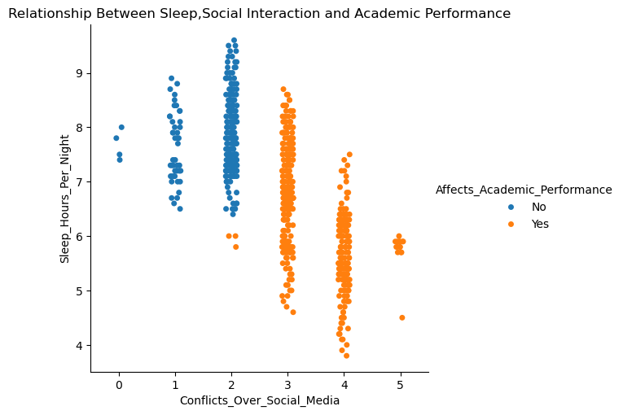

```python
#Sleep patterns, Academic performance, Social interaction
plt.figure(figsize=(8,5))
sns.catplot(x='Conflicts_Over_Social_Media',y='Sleep_Hours_Per_Night',data=dataset,hue='Affects_Academic_Performance',kind='strip')
plt.title("Relationship Between Sleep,Social Interaction and Academic Performance")
plt.show()
```

**Conclusion : From the above visual, we can see that students who are having conflicts > 2, are having Affects over their Academic Performance and also Impacting their Sleep_Hours as well.**

## 3.2 Analyze via Demographic

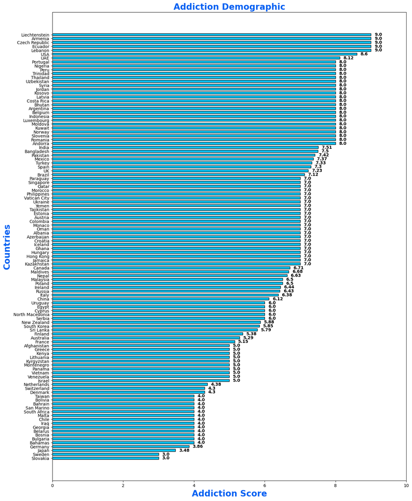

```python
#Analyse how addiction varies demograhically
plt.figure(figsize=(15,20))
country_group=round(dataset.groupby('Country')['Addicted_Score'].mean(),2)
country_sorted=country_group.sort_values(ascending=True)
x=country_sorted.index
y=country_sorted.values
plt.barh(x,y,edgecolor='black',color='#05C1F2',height=0.605)
plt.title("Addiction Demographic",color="#0560F2",weight='bold',size=20)
plt.xlabel("Addiction Score",color="#0560F2",weight='bold',size=20)
plt.ylabel("Countries",color="#0560F2",weight='bold',size=20)
for i in range(len(x)):
    plt.text(y[i]+0.1,x[i],y[i],ha='left',va='center',weight='demi')
plt.xlim(0,10)
plt.show()
```

**Conclusion : From the above visual, we can see that the students from countries like [Armenia,Ecuador,Czech Republic,Liechtenstein,Lebanon] are most addicted and students from countries like [Sweden,Slovakia,Japan,Germany] are least addicted**

# 4.Aggregations and Insights

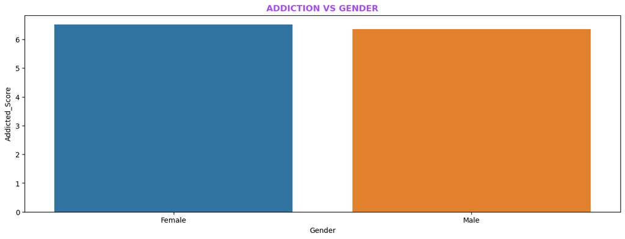

```python
#USE GROUPBY AND AGGREGATIONS TO FIND AVERAGE ADDICTION LEVEL ACCROSS DIFFERENT
#GENDER

plt.figure(figsize=(15,5))
gender_group = dataset.groupby('Gender')['Addicted_Score'].mean().reset_index()
sns.barplot(x='Gender',y='Addicted_Score',data=gender_group,hue='Gender')
plt.title("ADDICTION VS GENDER",color='#A24FF0',weight='bold')
plt.show()
```

**Conclusion : From the above plot, we can see that the FEMALE students are MORE Addicted to their phone whereas MALE students are LESS addicted to their phone.**

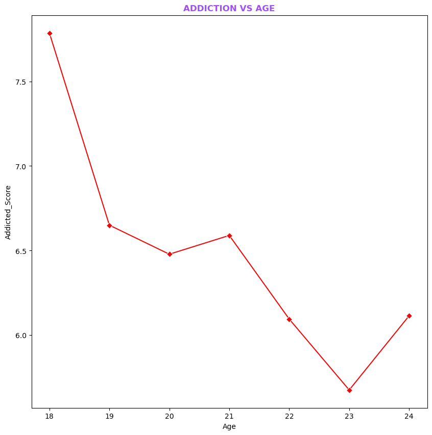

```python
#AGE GROUPS

plt.figure(figsize=(10,10))
age_grouped = dataset.groupby('Age')['Addicted_Score'].mean().reset_index()
sns.lineplot(x='Age',y='Addicted_Score',data=age_grouped,marker='D',color='#EB0909')
plt.title("ADDICTION VS AGE",color='#A24FF0',weight='bold')
plt.show()
```

**Conclusion : From the above plot, we can see that the students of Age:23 are LEAST Addicted to their phone whereas students of Age:18 are addicted MOST to their phone**

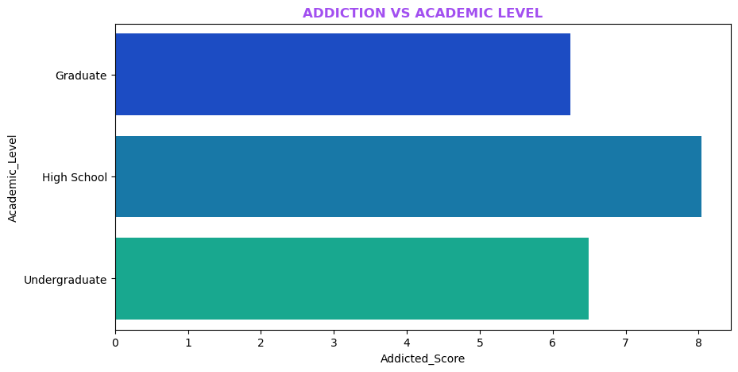

```python
# EDUCATION LEVEL

plt.figure(figsize=(10,5))
education_group = dataset.groupby('Academic_Level')['Addicted_Score'].mean().reset_index()
sns.barplot(y='Academic_Level',x='Addicted_Score',hue='Academic_Level',data=education_group,palette='winter')
plt.title('ADDICTION VS ACADEMIC LEVEL',color='#A24FF0',weight='bold')
plt.show()
```

**Conclusion : From the above plot, we can see that the students of GRADUATE are LEAST Addicted to their phone whereas students of HIGH SCHOOL are the MOST addicted to their phone**

# 5. FUNCTIONS,LOOPS AND CONDITIONALS

```python
dataset.head(3)
```

|  | Student_ID | Age | Gender | Academic_Level | Country | Avg_Daily_Usage_Hours | Most_Used_Platform | Affects_Academic_Performance | Sleep_Hours_Per_Night | Mental_Health_Score | Relationship_Status | Conflicts_Over_Social_Media | Addicted_Score |
| --- | --- | --- | --- | --- | --- | --- | --- | --- | --- | --- | --- | --- | --- |
| 0 | 1 | 19 | Female | Undergraduate | Bangladesh | 5.2 | Instagram | Yes | 6.5 | 6 | In Relationship | 3 | 8 |
| 1 | 2 | 22 | Male | Graduate | India | 2.1 | Twitter | No | 7.5 | 8 | Single | 0 | 3 |
| 2 | 3 | 20 | Female | Undergraduate | USA | 6.0 | TikTok | Yes | 5.0 | 5 | Complicated | 4 | 9 |

```python
# Classify risk level (Low/Medium/High) based on usage hours
def Create_risk():
    conditions = [
        (dataset['Addicted_Score'] < 4),
        (dataset['Addicted_Score'] >= 4) & (dataset['Addicted_Score'] < 7),
        (dataset['Addicted_Score'] >= 7)
    ]

    choices = ['Low','Medium','High']

    dataset['Risk_Level'] = np.select(conditions,choices,default='Unknown')
    print(dataset)


print(Create_risk())
```

```
     Student_ID  Age  Gender Academic_Level     Country  \
0             1   19  Female  Undergraduate  Bangladesh
1             2   22    Male       Graduate       India
2             3   20  Female  Undergraduate         USA
3             4   18    Male    High School          UK
4             5   21    Male       Graduate      Canada
..          ...  ...     ...            ...         ...
700         701   20  Female  Undergraduate       Italy
701         702   23    Male       Graduate      Russia
702         703   21  Female  Undergraduate       China
703         704   24    Male       Graduate       Japan
704         705   19  Female  Undergraduate      Poland

     Avg_Daily_Usage_Hours Most_Used_Platform Affects_Academic_Performance  \
0                      5.2          Instagram                          Yes
```

[output cut: 39 more lines]

```python
dataset.head(2)
```

|  | Student_ID | Age | Gender | Academic_Level | Country | Avg_Daily_Usage_Hours | Most_Used_Platform | Affects_Academic_Performance | Sleep_Hours_Per_Night | Mental_Health_Score | Relationship_Status | Conflicts_Over_Social_Media | Addicted_Score | Risk_Level |
| --- | --- | --- | --- | --- | --- | --- | --- | --- | --- | --- | --- | --- | --- | --- |
| 0 | 1 | 19 | Female | Undergraduate | Bangladesh | 5.2 | Instagram | Yes | 6.5 | 6 | In Relationship | 3 | 8 | High |
| 1 | 2 | 22 | Male | Graduate | India | 2.1 | Twitter | No | 7.5 | 8 | Single | 0 | 3 | Low |

```python
# EXPORT TO THE NEW CSV FILE.
dataset.to_csv('newupdated.csv',index=False)
```

```python
# Suggest digital detox strategies using if-else blocks
def process_column(dataset,column_name):
    column_data = dataset[column_name]
    for a in range(len(column_data)):
        if (column_data[a]=='High'):
            print(column_data[a] +" - Full-Day Disconnects: Schedule one full day per week with zero screen time to reset your habits and reconnect offline.")
        elif (column_data[a]=='Medium'):
            print(column_data[a] +" - Scheduled Screen Time: Set fixed time slots for digital use to prevent endless scrolling and regain control.")
        else:
            print(column_data[a] +" - Mindful Scrolling: Practice intentional use—pause before opening an app and ask yourself why you're doing it.")
digital_detox = process_column(dataset, 'Risk_Level')
print(digital_detox)
```

[output not shown]

[output cut: 651 more lines]

[output not shown]

# 6. Data Vizualization

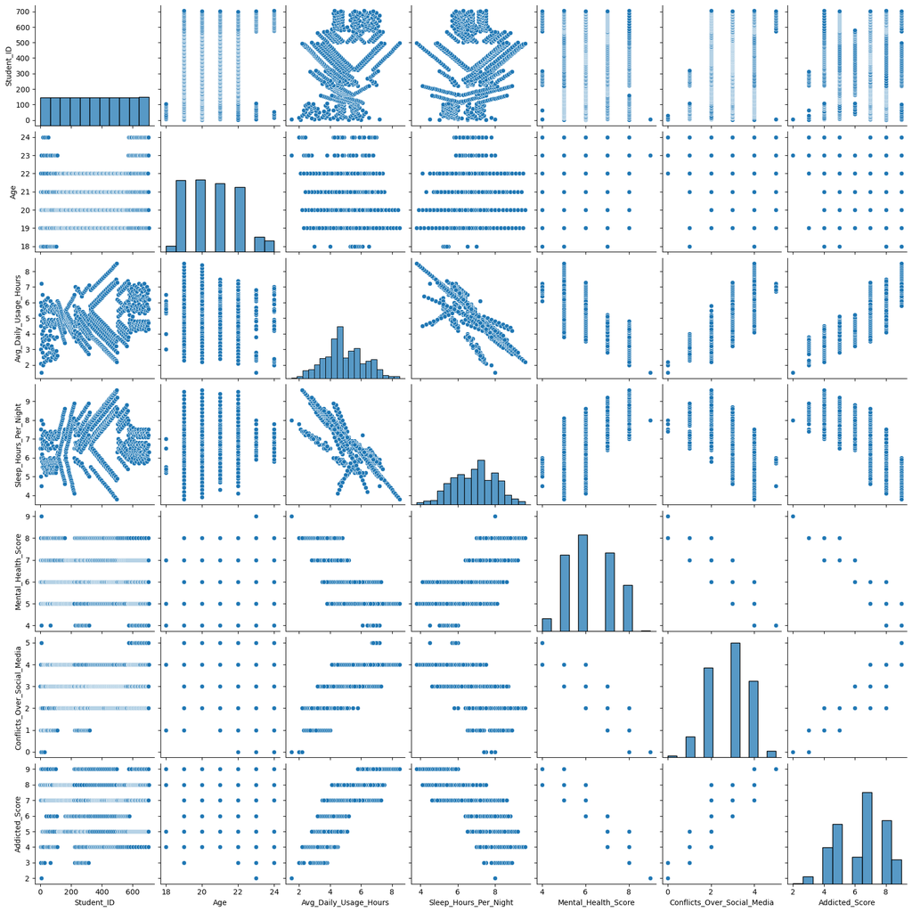

```python
# PAIR PLOT JUST TO KNOW WHAT ALL NUMERICAL DATA WE CAN CONSIDER FOR CHART PREPARATIONS.
sns.pairplot(data=dataset)
plt.show()
```

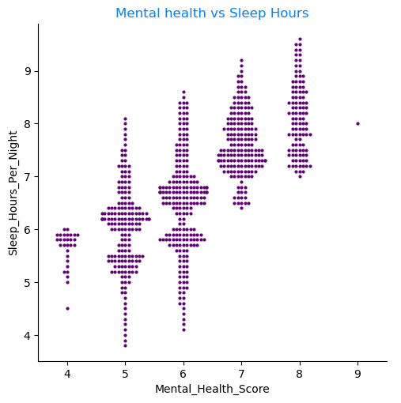

```python
# 1st CHART TO COMPARE RELATIONSHIP BETWEEN MENTAL HEALTH AND SLEEP HOURS.
sns.catplot(x='Mental_Health_Score',y='Sleep_Hours_Per_Night',data=dataset,kind='swarm',size=3,color='#600273')
plt.title("Mental health vs Sleep Hours",color='#0B80F4')
plt.show()
```

**Conclusion : From the above plot, we can see that the Mental Health Score of students have increased as their Sleep hours are increased.**

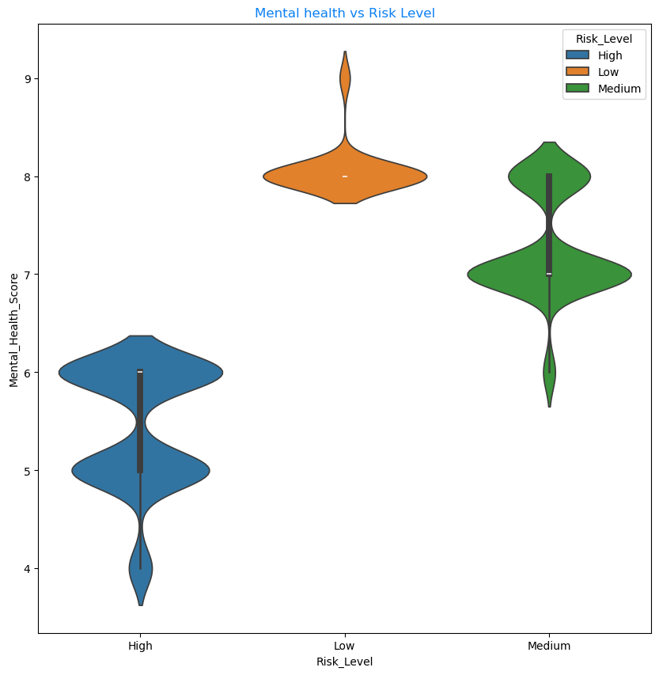

```python
#2nd CHART TO COMPARE RELATIONSHIP BETWEEN MENTAL HEALTH AND RISK LEVEL.
plt.figure(figsize=(10,10))
sns.violinplot(y='Mental_Health_Score',x='Risk_Level',data=dataset,hue='Risk_Level',legend=True)
plt.title("Mental health vs Risk Level",color='#0B80F4')
plt.show()
```

**Conclusion : From the above plot, we can see that the ADDICTED RISK_LEVEL is INDIRECTLY PROPORTIONAL TO MENTAL HEALTH SCORE. Meaning those students who are at LOW risk are in good Mental Health, whereas those who are at HIGH rish are having bad Mental Health.**

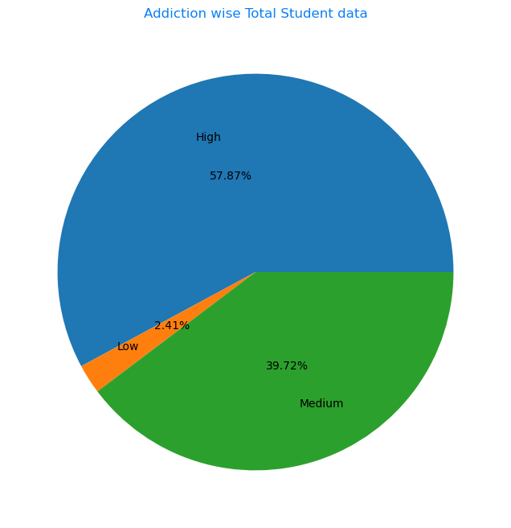

```python
# 3rd CHART TO COMPARE RELATIONSHIP BETWEEN ADDICTION AND STUDENT DATA
Std_count = dataset.groupby('Risk_Level')['Student_ID'].count()
plt.figure(figsize=(8, 8))
plt.pie(Std_count.values,labels=Std_count.index,autopct='%.2f%%',pctdistance=0.5,labeldistance=0.7)
plt.title('Addiction wise Total Student data',color='#0B80F4')
plt.show()
```

**Conclusion : From the above plot, we can see that the MORE than half population is HIGHLY Addicted, and less than 3% of students are LOW on addiction.**

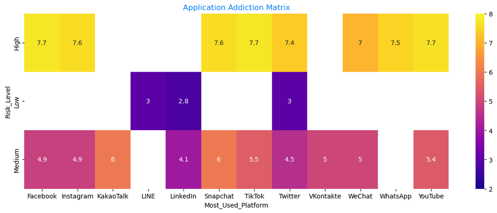

```python
# 4th CHART TO COMPARE RELATIONSHIP BETWEEN ADDICTION AND STUDENT DATA
pt2=pd.pivot_table(index='Risk_Level',columns='Most_Used_Platform',values='Addicted_Score',data=dataset)
plt.figure(figsize=(15,5))
sns.heatmap(pt2,annot=True,cmap='plasma',vmin=2,vmax=8)
plt.title("Application Addiction Matrix",color='#0B80F4')
plt.show()
```

# 7. Storytelling Deliverable

## 7.2 Root Causes

**Root Causes for such Addiction are as follows: -**  
*1. Lack of Education and Awareness - We need to organise more sessions on how to be digitally productive and not digitally addicted.*  
*2. Lack of self-control - We need to include a curriculum, which helps students with increasing their will-power, self-control, and more mindful exercises*  
*3. Session for parents - We need to organise sessions for parents, wherein they will be educated on how to track their children's digital addiction and help them with their issues*

## 7.3 Recommended Actions to Combat Addiction

**High Addiction Level**  
*Full-Day Disconnects: Schedule one full day per week with zero screen time to reset your habits and reconnect offline.*  
*App Blockers & Accountability: Use app blockers and share your goals with a friend or coach to stay accountable and reduce compulsive use.*  
**Medium Addiction Level**  
*Tech-Free Mornings: Avoid screens for the first hour after waking to build mindful routines and reduce dopamine spikes.*  
*Scheduled Screen Time: Set fixed time slots for digital use to prevent endless scrolling and regain control.*  
**Low Addiction Level**  
*Digital Sabbaths: Take short breaks (e.g., Sunday evenings) to reflect, journal, or enjoy nature without devices.*  
*Mindful Scrolling: Practice intentional use—pause before opening an app and ask yourself why you're doing it.*  
****OVERALLY WE CAN FOLLOW THE BELOW ACTIONS, IRRESPECTIVE OF OUR ADDICTION LEVEL****  
*Mindful Activities: You can perform breath awareness, mindful walking, and gratitude journaling*  
*Meditation: You can meditate, focus on breath, early in the morning to start your day energetically.*  
*Yoga/Exercise: It will keep your Body fit, which will help you to keep your Mind Healthy*  
**UTILISE TIME TO DO PRODUCTIVE ACTIVITIES, BEING OFF THE SCREEN. WHEN ON SCREEN, UTILISE THE APPLICATIONS FOR YOUR GOOD**